# Reproducible Research Project 1

Tessa Jones

January 20, 2016

The following outlines the basic analysis of data retrieved from a personal activity monitoring device that measures the number of steps taken by an individual at 5 m inute intervals over the course of two months.

Step one is to import to csv file with the activity data.

```r
library(plyr)
setwd('C:/excercisedata/repdata-data-activity')
data <- read.csv('activity.csv', stringsAsFactors= FALSE)
```

The total number of steps taken per day is summarized below and displayed as a histogram.

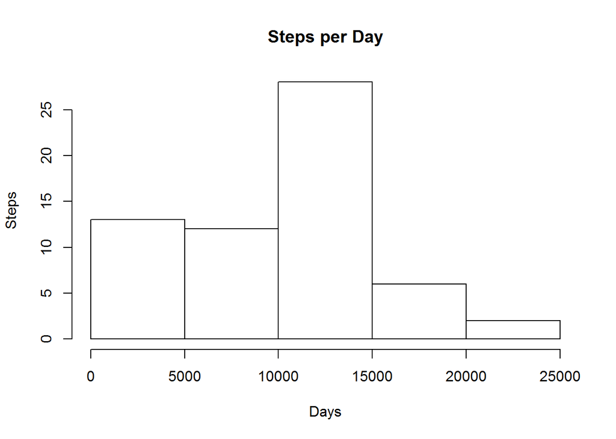

```r
sumbyday <- ddply(data, .(date), summarize, sum = sum(steps, na.rm = TRUE))
hist(sumbyday$sum, xlab = 'Days', ylab = 'Steps', main = 'Steps per Day')
```

```r
mean(data$steps, na.rm = TRUE)
```

```
## [1] 37.3826
```

```r
median(data$steps, na.rm = TRUE)
```

```
## [1] 0
```

A time series plot below was generated to identify the average daily activity. The 5 minute time interval that, on average, has the most number of steps is 835.

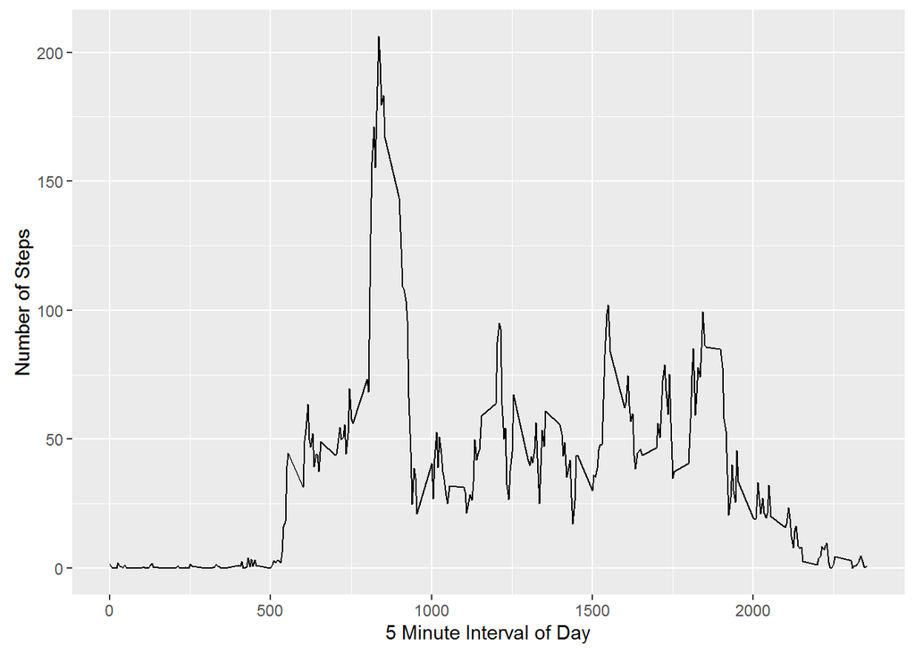

```r
meanbyint <- ddply(data, .(interval), summarize, mean=mean(steps, na.rm = TRUE))
library(ggplot2)
ggplot(meanbyint, aes(interval, mean)) + geom_line() + xlab("5 Minute Interval of Day") + ylab("Number of Steps")
```

```r
sum(is.na(data$steps))
```

```
## [1] 2304
```

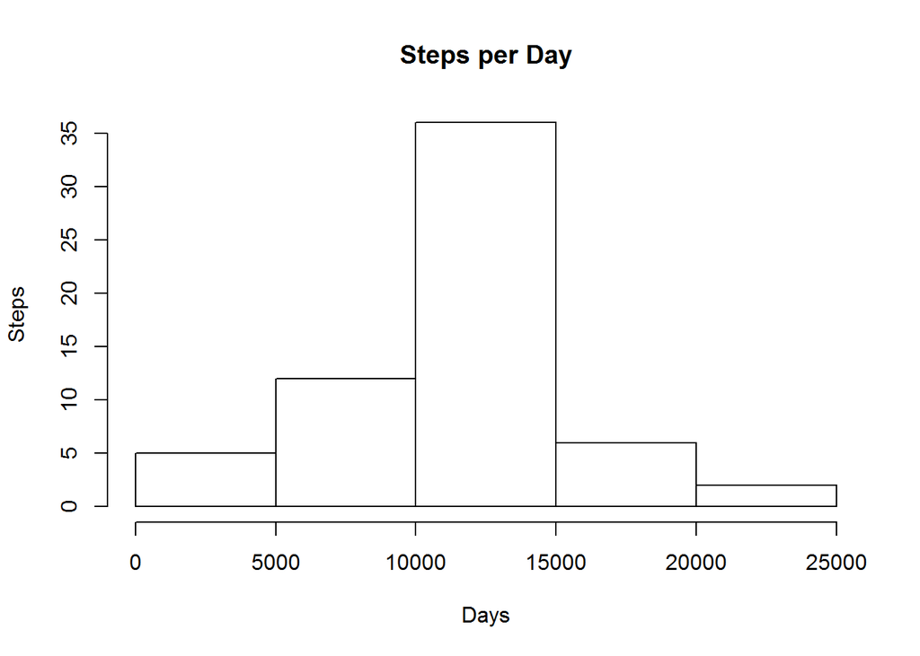

```r
sub1 <- merge(x = data, y = meanbyint, by = "interval", all.y = TRUE)
sub2 <- transform(sub1, steps=ifelse(is.na(sub1$steps),sub1$mean, sub1$steps))
sumbyday2 <- ddply(sub2, .(date), summarize, sum = sum(steps, na.rm = TRUE))
hist(sumbyday2$sum, xlab = 'Days', ylab = 'Steps', main = 'Steps per Day')
```

```r
mean(sub2$steps, na.rm = TRUE)
```

```
## [1] 37.3826
```

```r
median(sub2$steps, na.rm = TRUE)
```

```
## [1] 0
```

Now we want to compare the differences in activity between weekends and weekdays. The dates have been defined as being either a weeday or a weekend and a panel plot was generated to differentiate between the steps at each interval between weekends and weekdays.

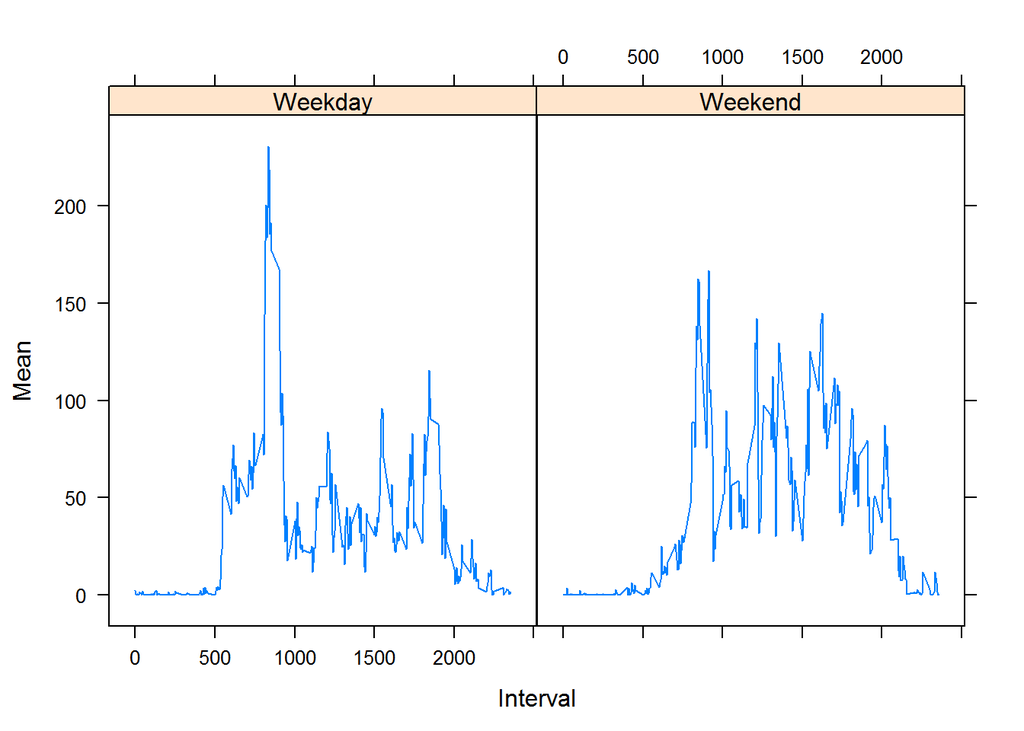

```r
sub2$day <- weekdays(as.Date(sub2$date))
sub2[sub2$day %in% c("Saturday", "Sunday"),]$day <- "Weekend"
sub2[sub2$day %in% c("Monday", "Tuesday","Wednesday","Thursday","Friday"),]$day <- "Weekday"
sub2 <- ddply(sub2, .(interval,day), summarise, meanReal=mean(steps))
library(lattice)
xyplot(sub2$meanReal~sub2$interval|sub2$day, type = 'l', xlab = 'Interval', ylab = 'Mean')
```